# Part_II_slide_deck_template slides

## Investigation Overview

Our analysis consisted to performe an exploratory and explicative visual analysis of the prosper loan dataset and find out what factors affect a BorrowerAPR and borrower’s interest rate (BorrowerRate). Through this exploration, we discovered that most of the borrowers come from The California State, and we also find out that, the higher the Credit Score, the lower the BorrowerAPR and BorrowerRate. Also, retired people tend to have low APR and low rates, consequently, enduring lower costs on loans compared to part-timers.

## Dataset Overview

We started our analysis with 113,937 records and 81 variables. After the Wrangling process we ended up with 22570 record and 19 variables.

## (Visualization 1)

From the barchart, we can oberved see that most of the borrowers come from California and illinois State. This could be a good business opportunity for lenders to open more agencies for loans in California State.

```
Text(0.5,1,'Distribution of loans by States')
```

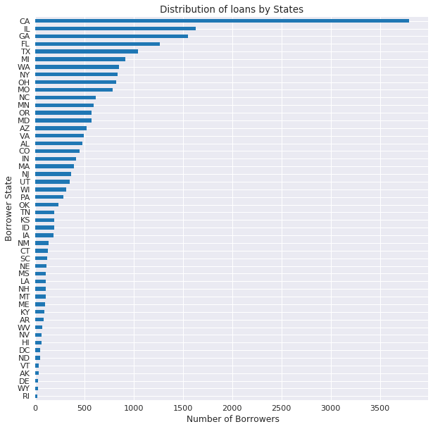

## (Visualization 2)

From the heatmap plot, there is a strong positive correlation between BorrowerAPR and BorrowerRate, then between LoanOriginalAmount and MonthlyLoanPayment. On the other hand, the CreditScoreAVG negatively correlate with BorrowerAPR and BorrowerRate. This means the higher the borrower's credit score, the lower his loan's rate and annual percentage rate. Based on the heatmap observation we take a closer look between the BorrowerAPR and CreditScoreAvg with a Regression plot plot since these are two numeric variables.

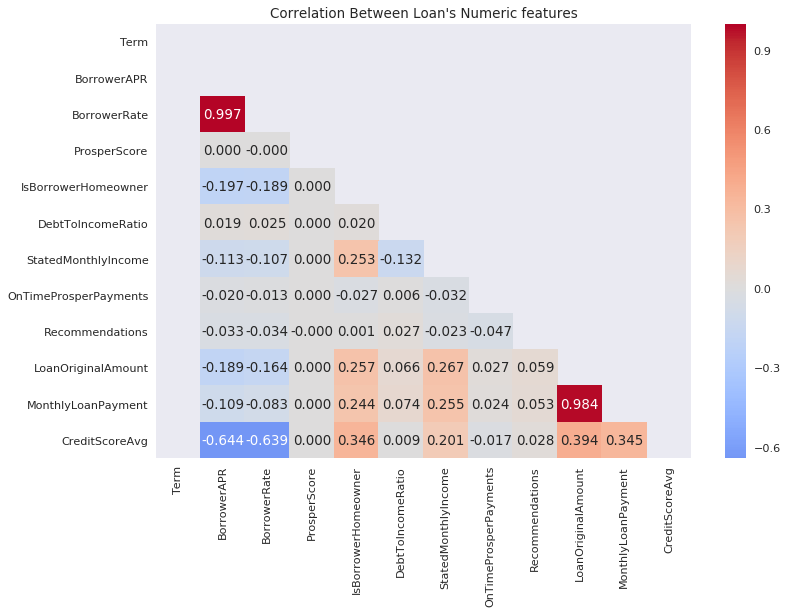

```
Text(0.5,0,'CreditScoreAvg')
```

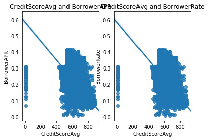

## (Visualization 3)

From a FacetGrid plot, we can see that part-timer in many listing category seems to have higher APR and BorrowerRate mode (AUto, Student use, Home improvement, Debt consolidation). On the other hand, retired people tend to have low APR and low Rates mode. As such, retired endure lower costs on loans compared to part-timers.

```
Text(0.5,0.98,'EmploymentStatus and ListingCategory influence on BorrowerRate')
```

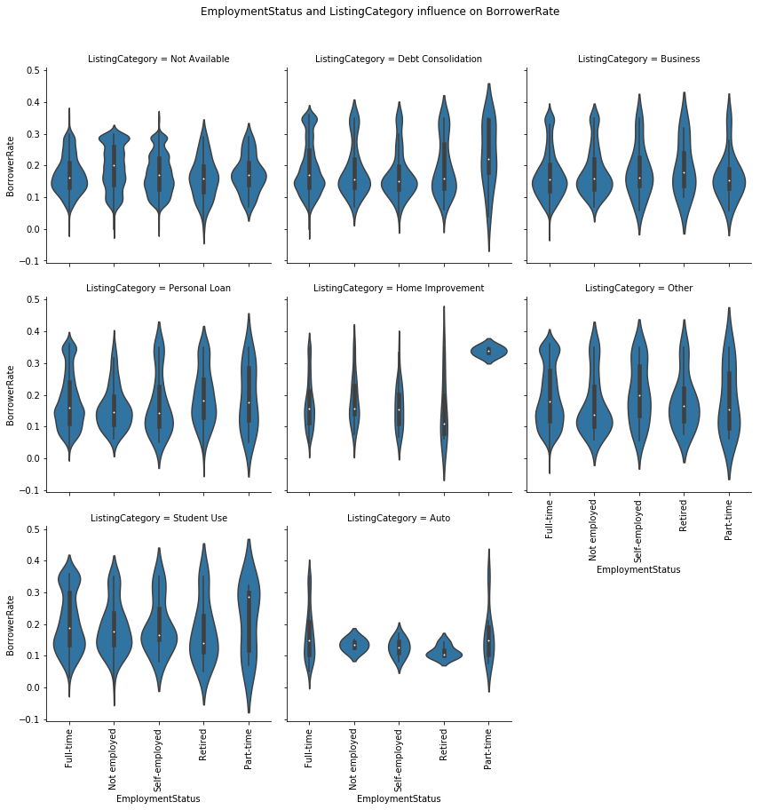